# Homework 4

aa2569@scarletmail.rutgers.edu

10/02/2022

## Time Series plot & ACF

```r
library(fpp)
```

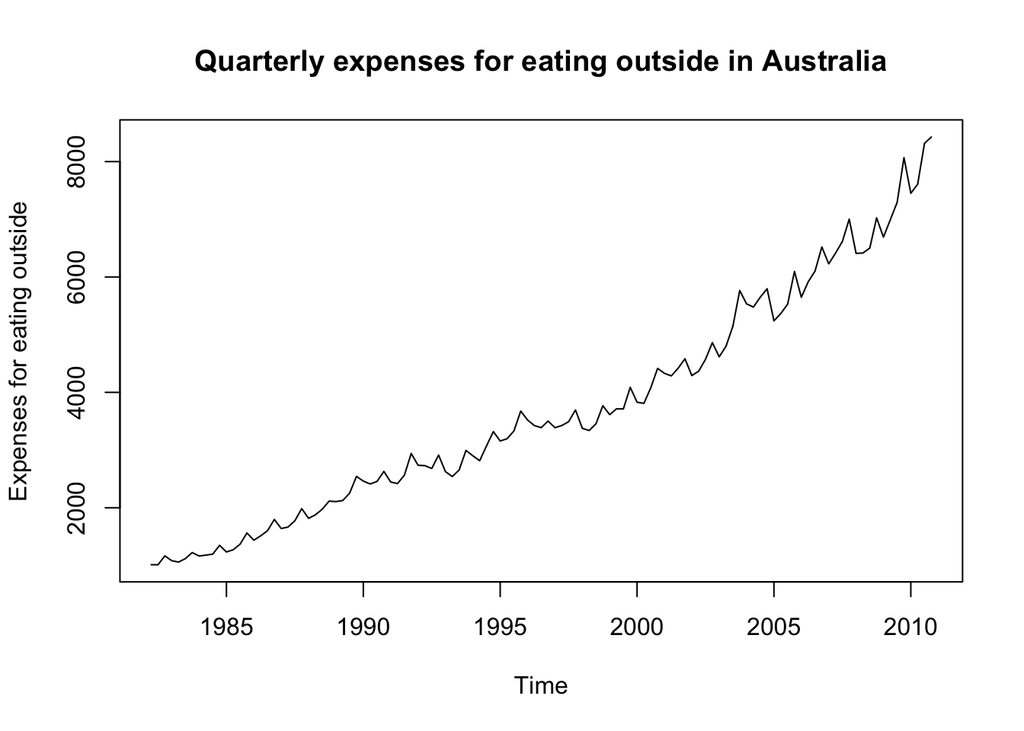

```r
plot(cafe,main = "Quarterly expenses for eating outside in Australia", xlab = "Time", ylab="Expenses for eating outside")
```

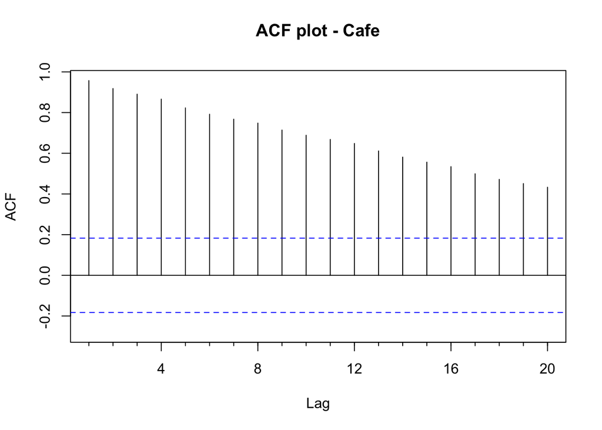

```r
Acf(cafe, main = "ACF plot - Cafe")
```

## Plotting Mean Forecast

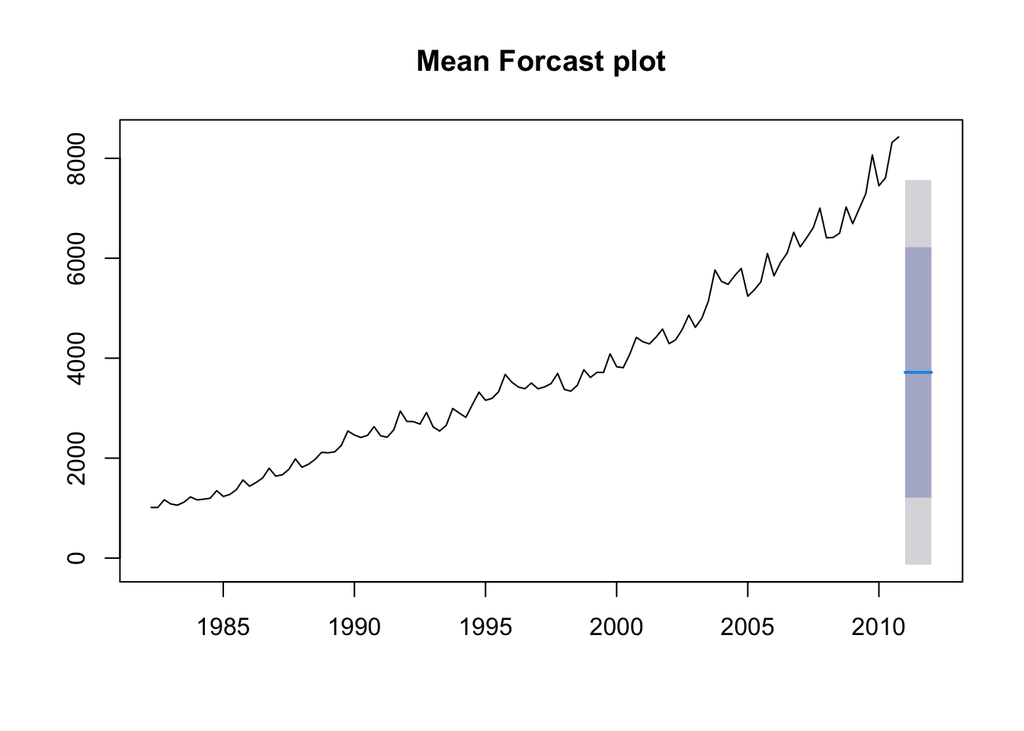

```r
mean_forecast <- meanf(cafe,5)
plot(mean_forecast, main = "Mean Forcast plot")
```

- The Mean Forcast plot takes the mean of the history of data and plots the mean as the future forecast.
- It can be observed that the this forecast is not the right one to go with. We can observe an increasing trend in the data and the mean forecast doesn’t provide the correct forecast.

## Naive Plot

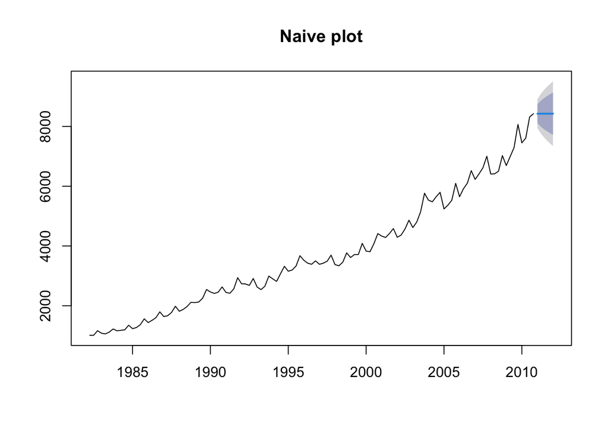

```r
naive_forecast <- naive(cafe,5)
plot(naive_forecast, main = "Naive plot")
```

- The naive plot take the last/latest data point as the forecast for the coming period.
- This is considered to be the basic forecast.
- As we can see, it is much more meaningful than the mean forecast.
- One drawback we can see for this data is that it is not considering the increasing trend.